# Red Wine Analysis by Taylor Van Daff

> **Tip**: This dataset is related to red variants of the Portuguese “Vinho Verde” wine.Input variables are as follows:  
> 1 - fixed acidity (tartaric acid - g / dm^3) 2 - volatile acidity (acetic acid - g / dm^3) 3 - citric acid (g / dm^3) 4 - residual sugar (g / dm^3) 5 - chlorides (sodium chloride - g / dm^3 6 - free sulfur dioxide (mg / dm^3) 7 - total sulfur dioxide (mg / dm^3) 8 - density (g / cm^3) 9 - pH 10 - sulphates (potassium sulphate - g / dm3) 11 - alcohol (% by volume) Output variable (based on sensory data): 12 - quality (score between 0 and 10)

# Univariate Plots Section

```
##   X fixed.acidity volatile.acidity citric.acid residual.sugar chlorides
## 1 1           7.4             0.70        0.00            1.9     0.076
## 2 2           7.8             0.88        0.00            2.6     0.098
## 3 3           7.8             0.76        0.04            2.3     0.092
## 4 4          11.2             0.28        0.56            1.9     0.075
## 5 5           7.4             0.70        0.00            1.9     0.076
## 6 6           7.4             0.66        0.00            1.8     0.075
##   free.sulfur.dioxide total.sulfur.dioxide density   pH sulphates alcohol
## 1                  11                   34  0.9978 3.51      0.56     9.4
## 2                  25                   67  0.9968 3.20      0.68     9.8
## 3                  15                   54  0.9970 3.26      0.65     9.8
## 4                  17                   60  0.9980 3.16      0.58     9.8
## 5                  11                   34  0.9978 3.51      0.56     9.4
## 6                  13                   40  0.9978 3.51      0.56     9.4
##   quality
## 1       5
## 2       5
## 3       5
## 4       6
## 5       5
## 6       5
```

```
##        X          fixed.acidity   volatile.acidity  citric.acid
##  Min.   :   1.0   Min.   : 4.60   Min.   :0.1200   Min.   :0.000
##  1st Qu.: 400.5   1st Qu.: 7.10   1st Qu.:0.3900   1st Qu.:0.090
##  Median : 800.0   Median : 7.90   Median :0.5200   Median :0.260
##  Mean   : 800.0   Mean   : 8.32   Mean   :0.5278   Mean   :0.271
##  3rd Qu.:1199.5   3rd Qu.: 9.20   3rd Qu.:0.6400   3rd Qu.:0.420
##  Max.   :1599.0   Max.   :15.90   Max.   :1.5800   Max.   :1.000
##  residual.sugar     chlorides       free.sulfur.dioxide
##  Min.   : 0.900   Min.   :0.01200   Min.   : 1.00
##  1st Qu.: 1.900   1st Qu.:0.07000   1st Qu.: 7.00
##  Median : 2.200   Median :0.07900   Median :14.00
##  Mean   : 2.539   Mean   :0.08747   Mean   :15.87
##  3rd Qu.: 2.600   3rd Qu.:0.09000   3rd Qu.:21.00
##  Max.   :15.500   Max.   :0.61100   Max.   :72.00
##  total.sulfur.dioxide    density             pH          sulphates
##  Min.   :  6.00       Min.   :0.9901   Min.   :2.740   Min.   :0.3300
##  1st Qu.: 22.00       1st Qu.:0.9956   1st Qu.:3.210   1st Qu.:0.5500
##  Median : 38.00       Median :0.9968   Median :3.310   Median :0.6200
##  Mean   : 46.47       Mean   :0.9967   Mean   :3.311   Mean   :0.6581
##  3rd Qu.: 62.00       3rd Qu.:0.9978   3rd Qu.:3.400   3rd Qu.:0.7300
##  Max.   :289.00       Max.   :1.0037   Max.   :4.010   Max.   :2.0000
##     alcohol         quality
##  Min.   : 8.40   Min.   :3.000
##  1st Qu.: 9.50   1st Qu.:5.000
##  Median :10.20   Median :6.000
##  Mean   :10.42   Mean   :5.636
##  3rd Qu.:11.10   3rd Qu.:6.000
##  Max.   :14.90   Max.   :8.000
```

```
## redwine$quality: 3
##    Min. 1st Qu.  Median    Mean 3rd Qu.    Max.
##  0.9947  0.9961  0.9976  0.9975  0.9988  1.0008
## --------------------------------------------------------
## redwine$quality: 4
##    Min. 1st Qu.  Median    Mean 3rd Qu.    Max.
##  0.9934  0.9957  0.9965  0.9965  0.9974  1.0010
## --------------------------------------------------------
## redwine$quality: 5
##    Min. 1st Qu.  Median    Mean 3rd Qu.    Max.
##  0.9926  0.9962  0.9970  0.9971  0.9979  1.0031
## --------------------------------------------------------
## redwine$quality: 6
##    Min. 1st Qu.  Median    Mean 3rd Qu.    Max.
##  0.9901  0.9954  0.9966  0.9966  0.9979  1.0037
## --------------------------------------------------------
## redwine$quality: 7
##    Min. 1st Qu.  Median    Mean 3rd Qu.    Max.
##  0.9906  0.9948  0.9958  0.9961  0.9974  1.0032
## --------------------------------------------------------
## redwine$quality: 8
##    Min. 1st Qu.  Median    Mean 3rd Qu.    Max.
##  0.9908  0.9942  0.9949  0.9952  0.9972  0.9988
```

```
## redwine$quality: 3
##    Min. 1st Qu.  Median    Mean 3rd Qu.    Max.
##   8.400   9.725   9.925   9.955  10.575  11.000
## --------------------------------------------------------
## redwine$quality: 4
##    Min. 1st Qu.  Median    Mean 3rd Qu.    Max.
##    9.00    9.60   10.00   10.27   11.00   13.10
## --------------------------------------------------------
## redwine$quality: 5
##    Min. 1st Qu.  Median    Mean 3rd Qu.    Max.
##     8.5     9.4     9.7     9.9    10.2    14.9
## --------------------------------------------------------
## redwine$quality: 6
##    Min. 1st Qu.  Median    Mean 3rd Qu.    Max.
##    8.40    9.80   10.50   10.63   11.30   14.00
## --------------------------------------------------------
## redwine$quality: 7
##    Min. 1st Qu.  Median    Mean 3rd Qu.    Max.
##    9.20   10.80   11.50   11.47   12.10   14.00
## --------------------------------------------------------
## redwine$quality: 8
##    Min. 1st Qu.  Median    Mean 3rd Qu.    Max.
##    9.80   11.32   12.15   12.09   12.88   14.00
```

```
## redwine$quality: 3
##    Min. 1st Qu.  Median    Mean 3rd Qu.    Max.
##   1.200   1.875   2.100   2.635   3.100   5.700
## --------------------------------------------------------
## redwine$quality: 4
##    Min. 1st Qu.  Median    Mean 3rd Qu.    Max.
##   1.300   1.900   2.100   2.694   2.800  12.900
## --------------------------------------------------------
## redwine$quality: 5
##    Min. 1st Qu.  Median    Mean 3rd Qu.    Max.
##   1.200   1.900   2.200   2.529   2.600  15.500
## --------------------------------------------------------
## redwine$quality: 6
##    Min. 1st Qu.  Median    Mean 3rd Qu.    Max.
##   0.900   1.900   2.200   2.477   2.500  15.400
## --------------------------------------------------------
## redwine$quality: 7
##    Min. 1st Qu.  Median    Mean 3rd Qu.    Max.
##   1.200   2.000   2.300   2.721   2.750   8.900
## --------------------------------------------------------
## redwine$quality: 8
##    Min. 1st Qu.  Median    Mean 3rd Qu.    Max.
##   1.400   1.800   2.100   2.578   2.600   6.400
```

```
## [1] "data.frame"
```

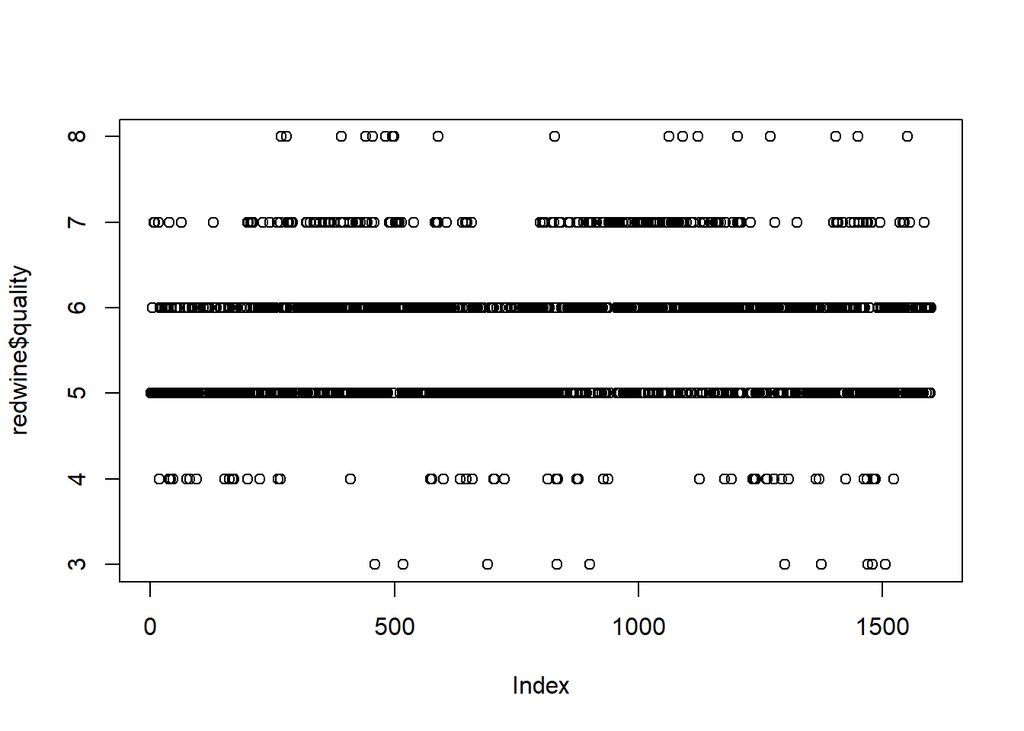

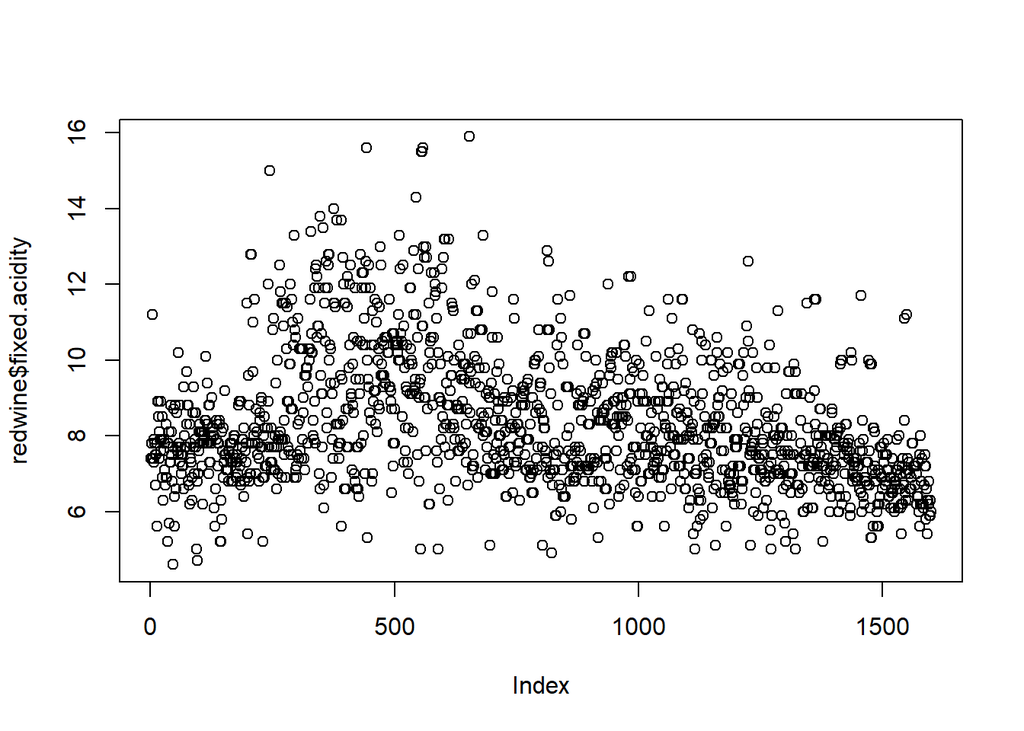

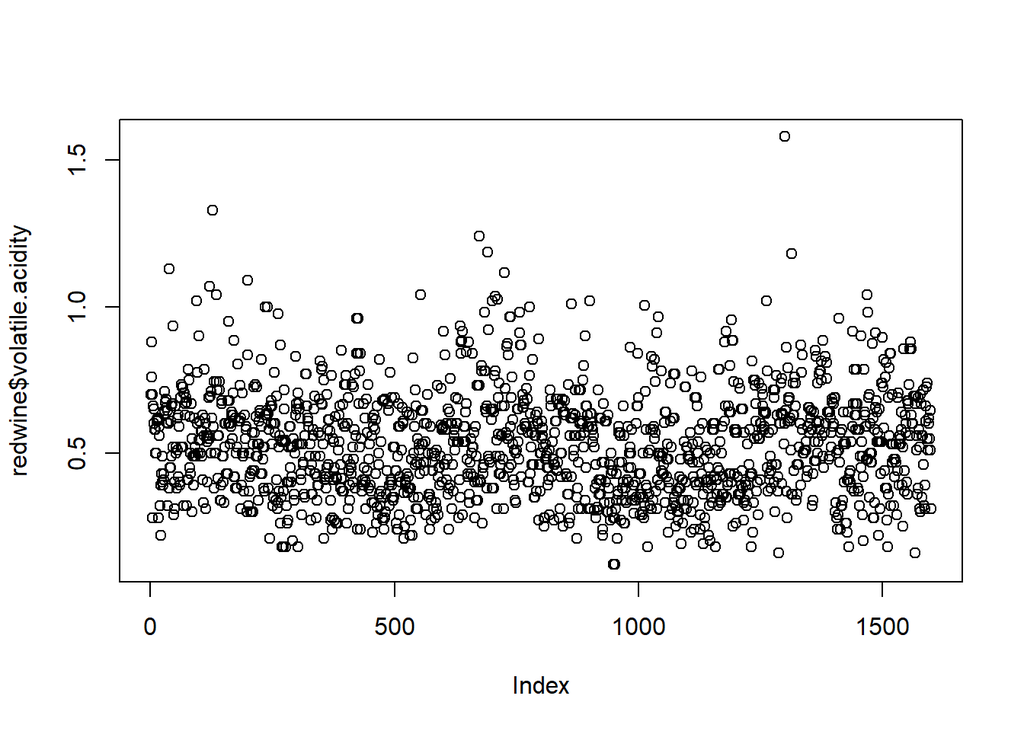

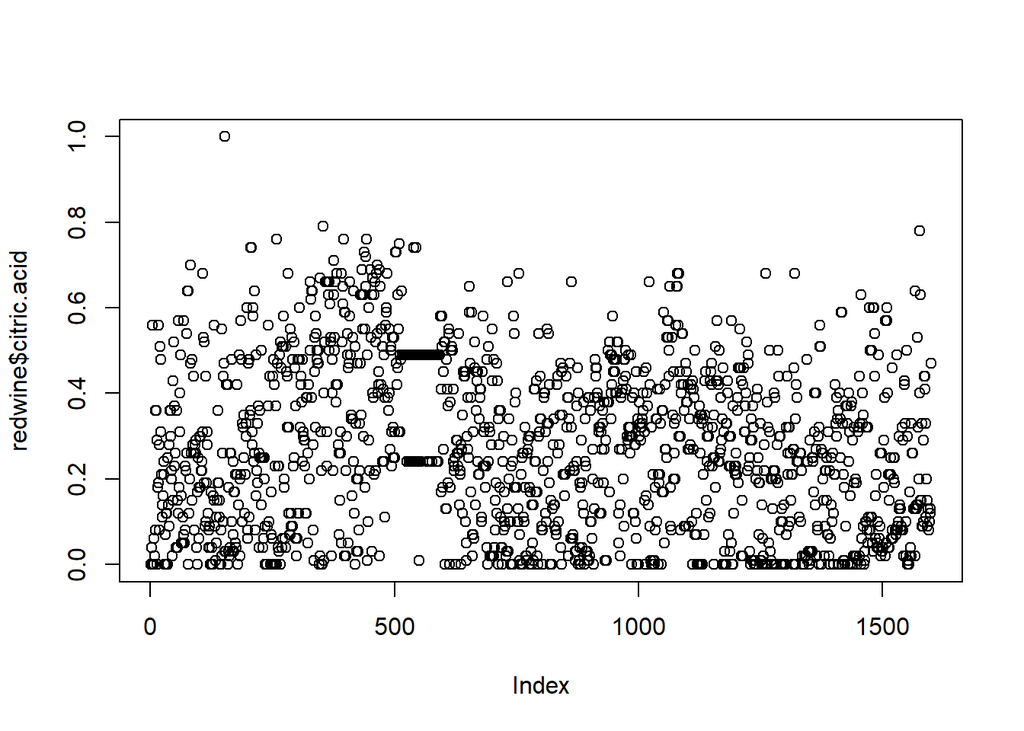

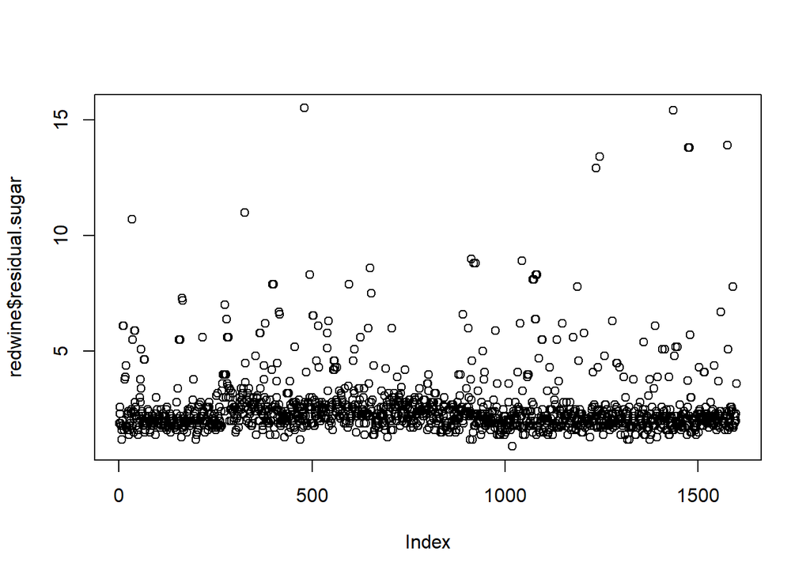

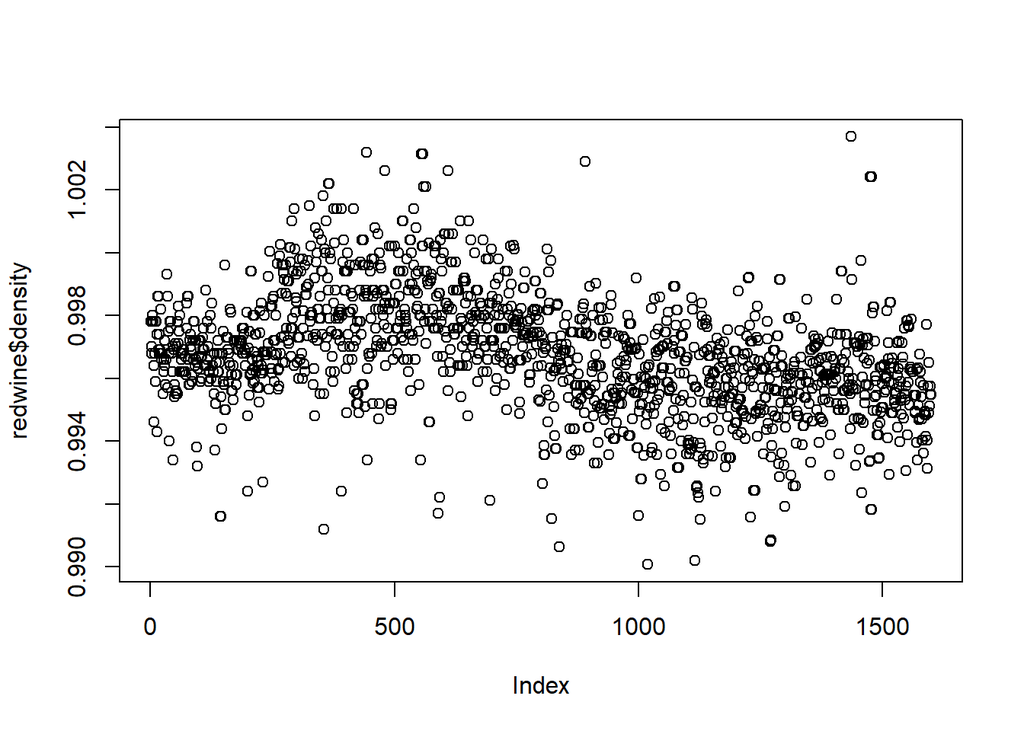

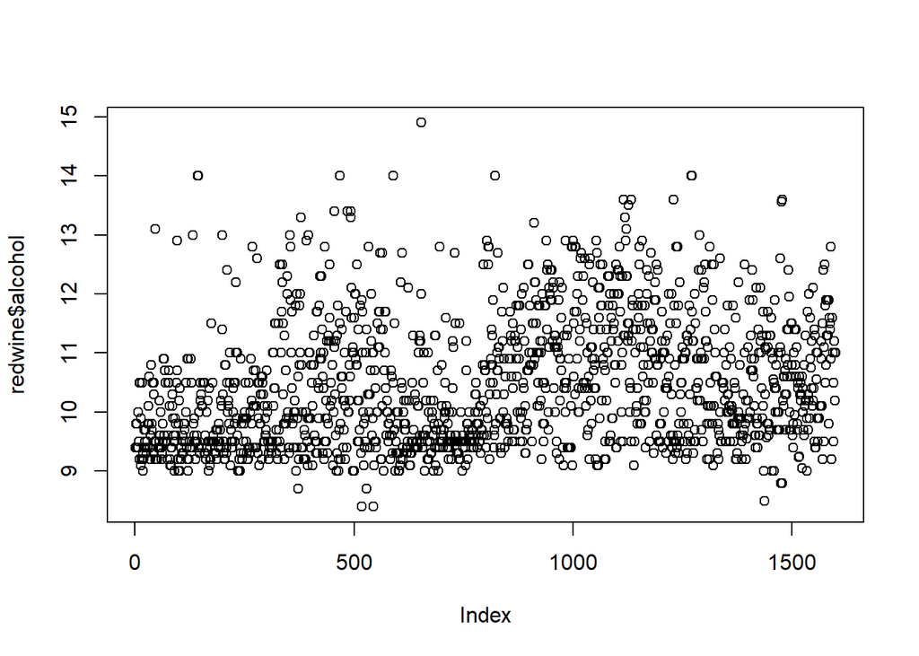

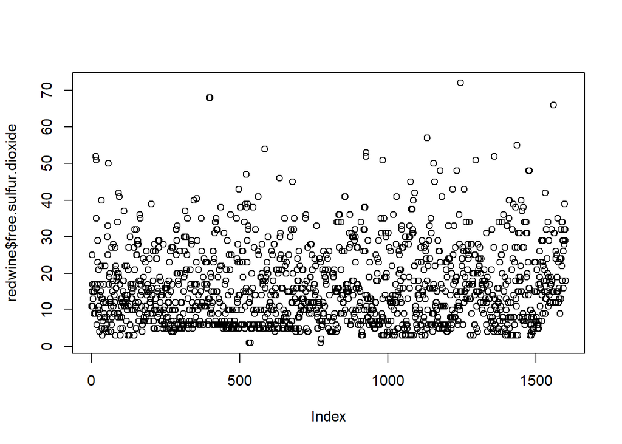

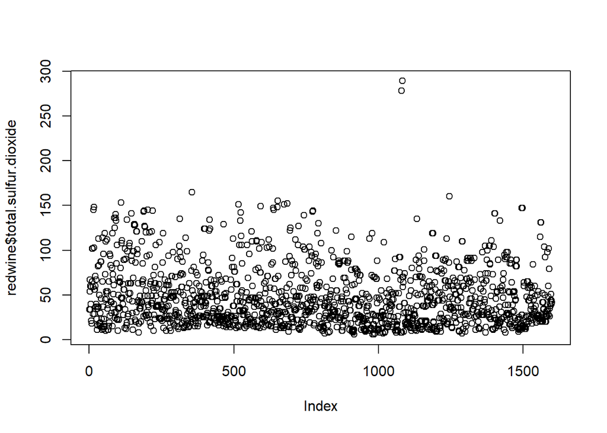

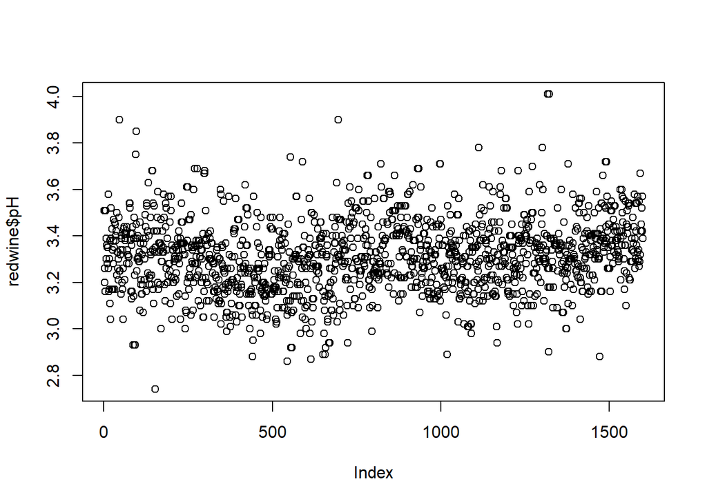

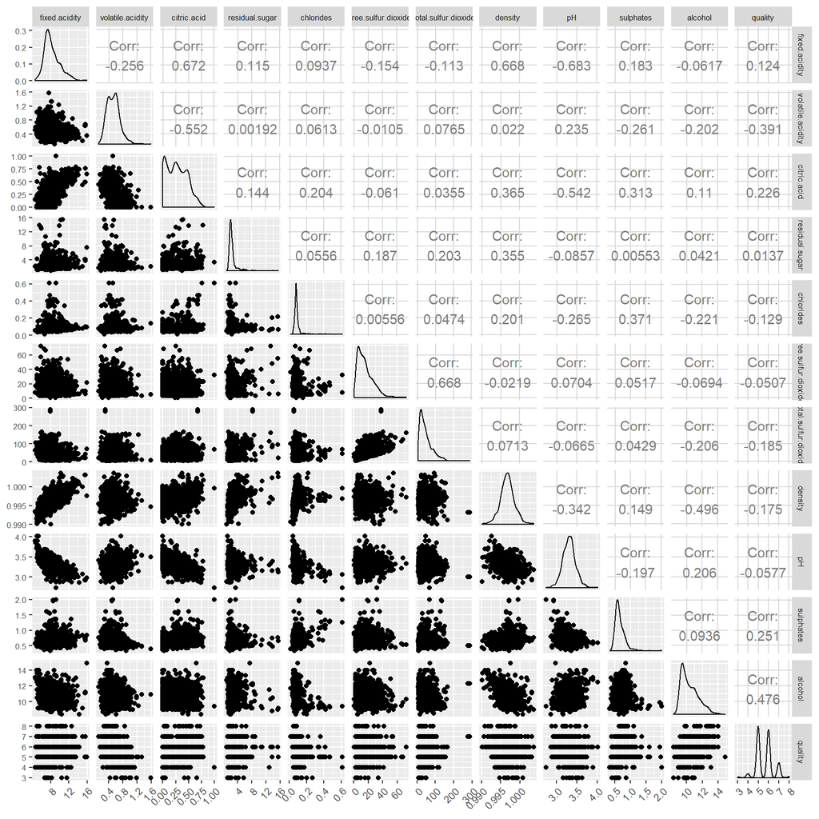

# Univariate Analysis

### What is the structure of your dataset?

There are 1599 observations with 13 variables. Each variable has the same length, allowing r to classify the dataset “redwine” as a data frame when the class() function is run. There are no strings in the dataframe, making manipulation fairly straightfoward.

### What is/are the main feature(s) of interest in your dataset?

The main feature of interest is the Quality variable and the effect other variables are bound to have on it. That is why I made this the main feature of this dataset. For practical purposes, the higher a manufacturer can make the quality of their wine, the more customers they can generate and the higher the price they can charge. This would likely be the most useful variable if any correlation can be determined between a variable and Quality.

### What other features in the dataset do you think will help support your investigation into your feature(s) of interest?

I think fixed acidity levels, citric acid levels, alcohol levels, and residual sugar would all play a certain role in flavoring the wine and thus affect the quality to some extent. That is why I chose to investigate these variables in particular. Their affect on the pallete would seem to be most straightforward.

### Did you create any new variables from existing variables in the dataset?

I did not. The variables in this dataset were already ripe for plotting. Density had been calculated, and the metrics used were all dress-right-dress.

# Bivariate Plots Section

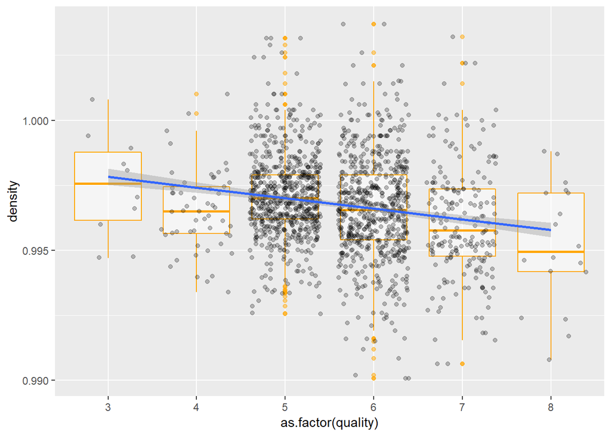

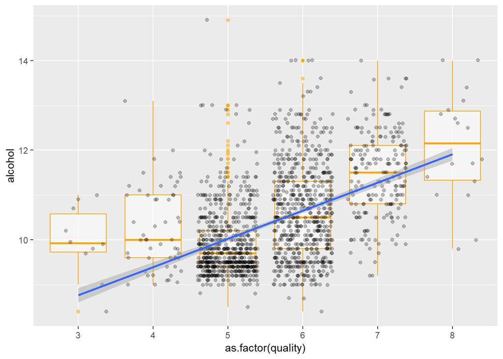

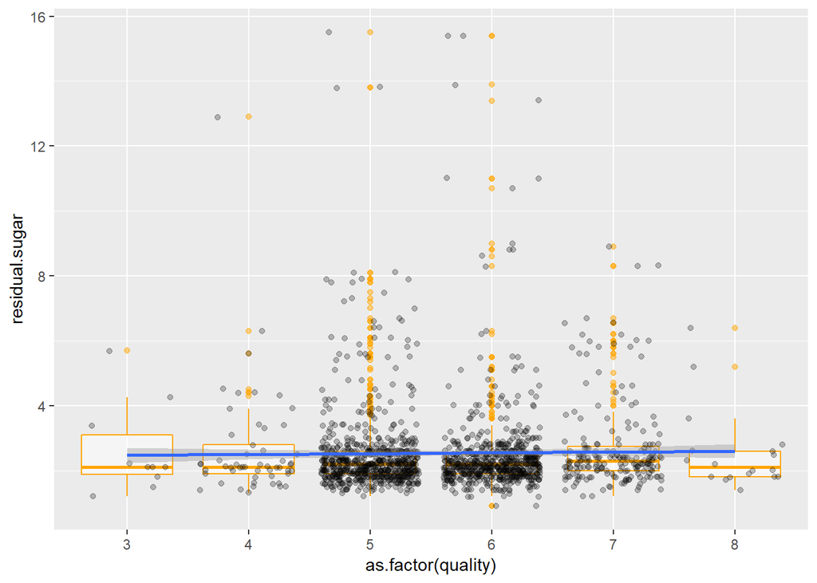

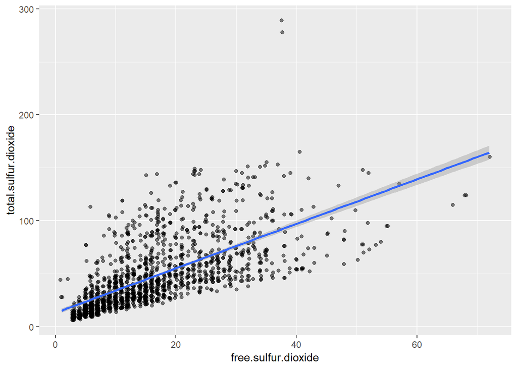

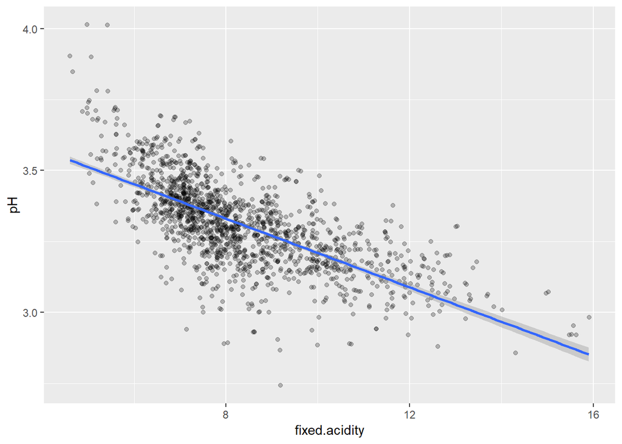

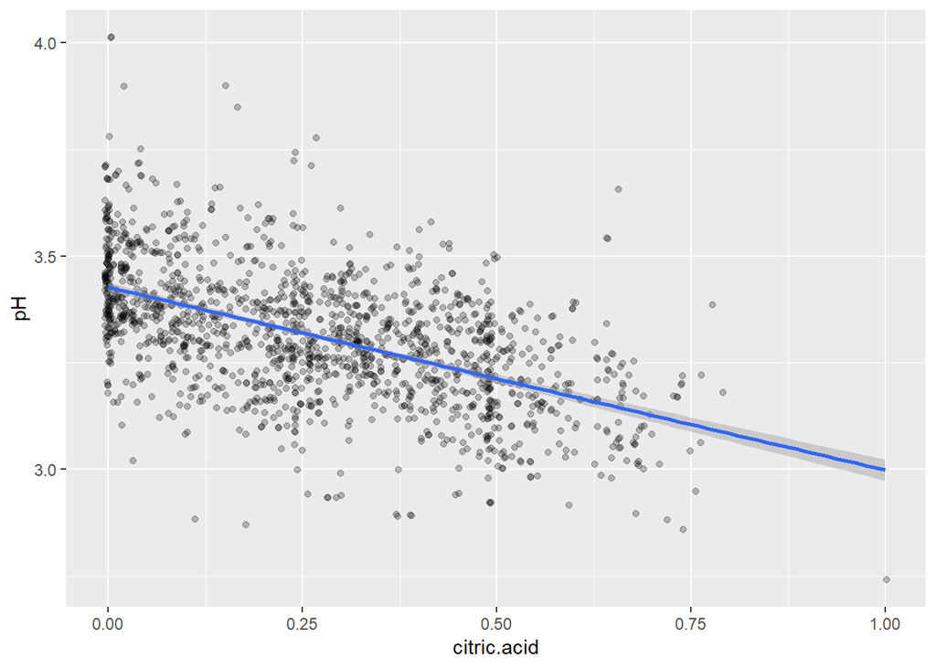

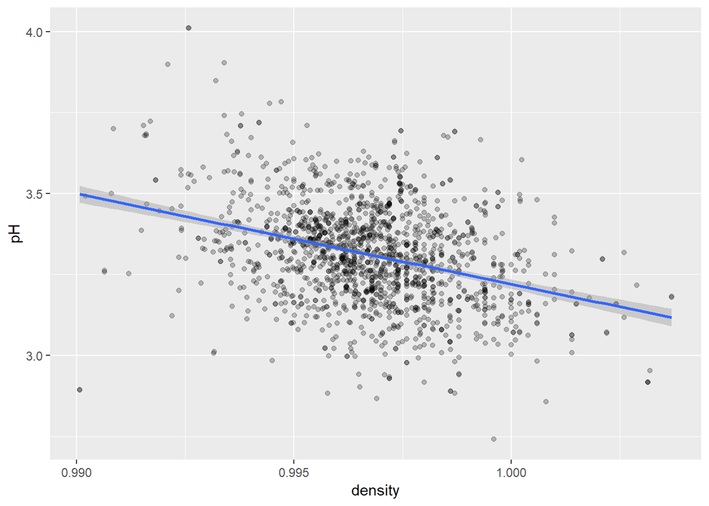

# Bivariate Analysis

### Talk about some of the relationships you observed in this part of the investigation. How did the feature(s) of interest vary with other features in the dataset?

The variable of interest here is quality. On average, we can see that the greater the density, the lower the quality. And the highest quality is more likely to be less dense. The variables are negatively correlated.

When quality was compared to alcohol, on the other hand show a positive correlation. The greater the alcohol content, the more likely the wine is to be of higher quality.

Lastly, when examining how residual sugar may affect quality level, it is clear in both a scatter plot/linear model and boxplot visual, that the residual sugar has little to no correlation with quality.

All of the above plots had a few similar features. The majority of the observations were of average-quality wines, with few observations in the bottom and upper quality levels. The graphs attempt to mitigate this with the use of alphas and jittering.

### Did you observe any interesting relationships between the other features (not the main feature(s) of interest)?

I observed a fairly interesting relationship between pH and fixed acidity. The negative correlation suggests that fixed acidity is highly predictive of pH.

Perhaps surprisingly, citric acid levels are the same way. The negative correlation demonstrates the more citric acid used in the wine, the lower the pH, or overall, the more acidic the wine will be.

### What was the strongest relationship you found?

The strongest relationship with the featured variable was between quality and alcohol content; the correlation here was .476.

# Multivariate Plots Section

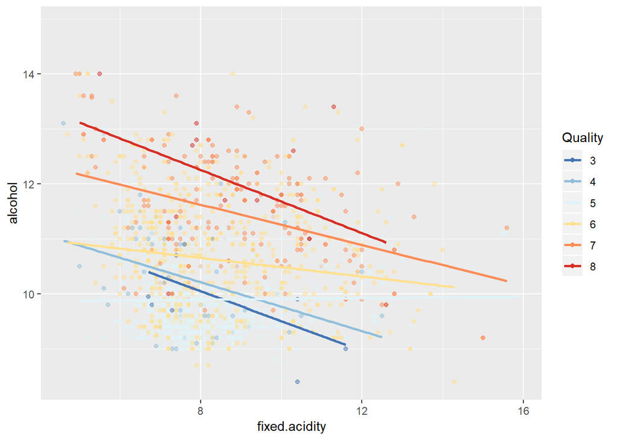

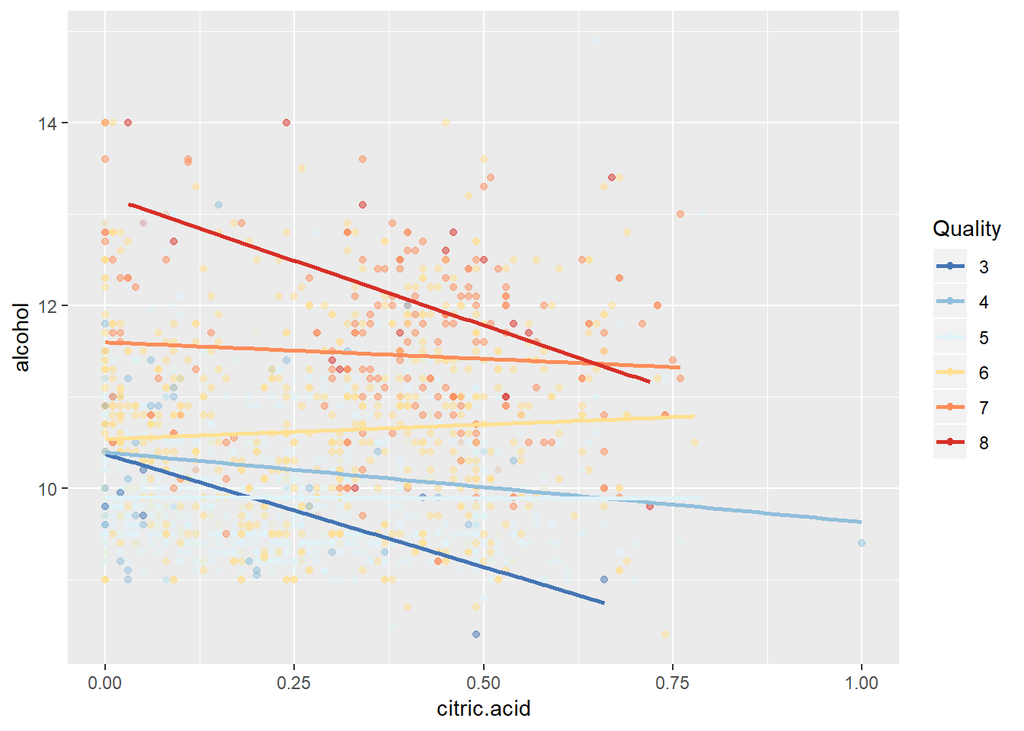

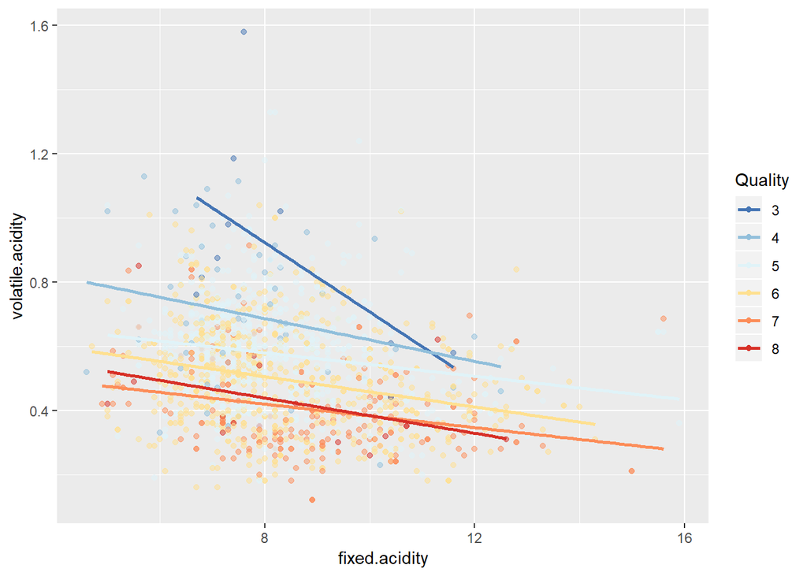

# Multivariate Analysis

### Talk about some of the relationships you observed in this part of the investigation. Were there features that strengthened each other in terms of looking at your feature(s) of interest?

What is interesting in the multivariate analysis is how the relationships between different variables change under each of the Quality labels.

Fixed acidity and alcohol have a similar steep negative correlation in the 3, 4, and 8 quality ratings, but a nearly flat line in 5 and 6. This showed also that, on average, the lower quality wines have more acidity and less alcohol while high quality wines have more alcohol and less acidity.

In general, there was also a steeply negative relationship between fixed and volatile acidity in the lesser quality rating, but the relationship flattens across ratings. meaning that there seems to be a limit to the volatile acidity levels as quality increases, though fixed acidity is liable to be high or low.

### Were there any interesting or surprising interactions between features?

I thought the most interesting interaction was that there was a limit to the volatile acidity levels as quality increases, though fixed acidity is liable to be high or low.

I also thought it was interesting how the relationships between variables shifted through different quality ratings. I think the major explanation for this is the amount of observations that tend to flatten the scatter plots around average quality ratings.

# Final Plots and Summary

### Plot One

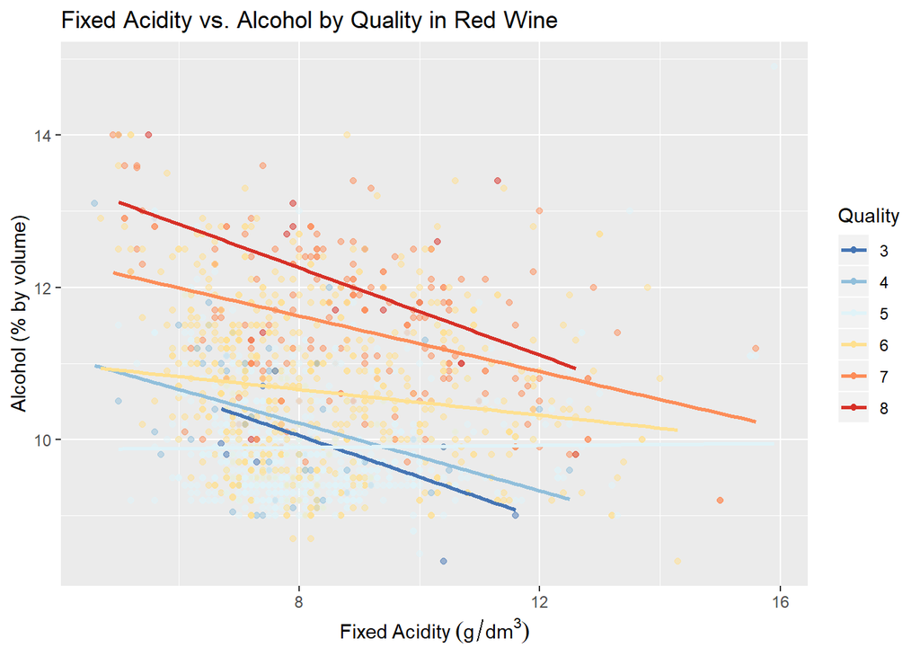

### Plot Two

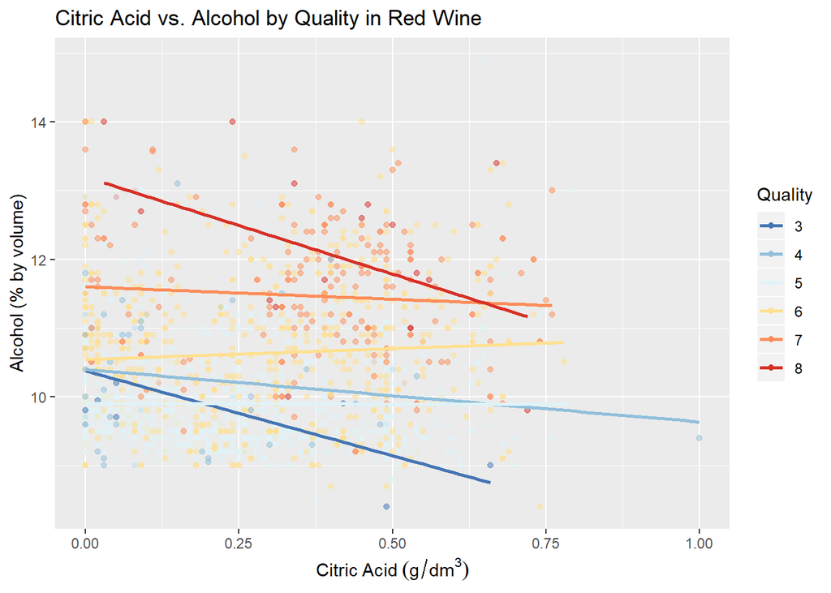

### Plot Three

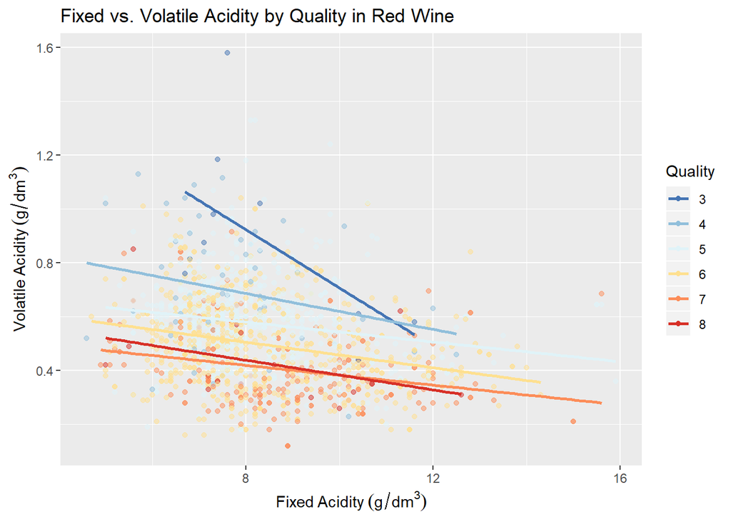

### Description Three

Here, the relationship between fixed acidity and volatile acidity is initially steeply negative, with the greater fixed acidity leading to less volatile acidity. The relationship flattens as there is less and less volatile acidity in higher quality wines, while fixed acidity does not change. This indicates that volatile acidity plays a strong predictive role in quality outcomes for wine.

# Reflection

I was curious about the relationship between different variables across quality in the event that certain levels of these variables are more common in higher quality red wine. I chose and explored the levels of fixed acidity, volatile acidity, citric acid, and alcohol to determine the effects different levels of these variables have. While moving through the analysis, I experienced trouble rearranging and layering graphs for better visualizations. With the help of a reviewer, I realized the proper coding, how to color by layers, and how to add in units of measurement. I also found it difficult to analyze relationships in this dataset because some of them are fairly intuitive, while others are not at all correlated. Filtering the graphs and using a small alpha helped in determining a clearer picture. In the end, this exploration looks into numerous variables as they affect quality. This has determined that there are a few main contenders in affecting the quality of wine: alcohol, volatile acidity, while other variables like density aren’t as strong, and those like residual sugar don’t have any affect at all. The main struggle in analysis is the shear lack of data across varying levels of quality, which tremendously skew the results. I thought the multivariate analysis went surprisingly well. It built off previous plots and dove deep into the intricacies of variable relationships. From these results, more research can show the perfect levels of volatile acidity and alcohol levels to concoct the proper high-quality red wine. This future analysis should expand to include more observations evenly dispersed across quality levels.